# ST_02_3

```r
exo9 <- read.table("exo9.txt",h=T,sep="\t",dec=",") %>% as_tibble() %>% mutate_at(c("P","TRT","S","US"),as.factor)
```

| P | TRT | S | n |
| --- | --- | --- | --- |
| 1 | 1 | 1 | 5 |
| 1 | 2 | 2 | 5 |
| 2 | 1 | 2 | 5 |
| 2 | 2 | 1 | 5 |

```r
aov9 <- lm(TEMP ~ 1 + TRT + P + S + US%in%S + TRT:P + TRT:S + P:S,data=exo9)
anova(aov9)
```

```
Analysis of Variance Table

Response: TEMP
          Df Sum Sq Mean Sq F value  Pr(>F)
TRT        1  0.288   0.288  3.8400 0.08571 .
P          1  0.032   0.032  0.4267 0.53195
S          1  0.128   0.128  1.7067 0.22772
S:US       8  0.200   0.025  0.3333 0.92944
Residuals  8  0.600   0.075
---
Signif. codes:  0 ‘***’ 0.001 ‘**’ 0.01 ‘*’ 0.05 ‘.’ 0.1 ‘ ’ 1
```

```r
pf(0.128/0.025,1,8,lower.tail = F)
```

```
[1] 0.05349299
```

# Analyse de la covariance

```r
anacov <- read_tsv("http://www.biostat.envt.fr/wp-content/uploads/Enseignement/Etudiants/anacov.txt")%>% mutate_at(vars(Porc,Sexe),as.factor)
```

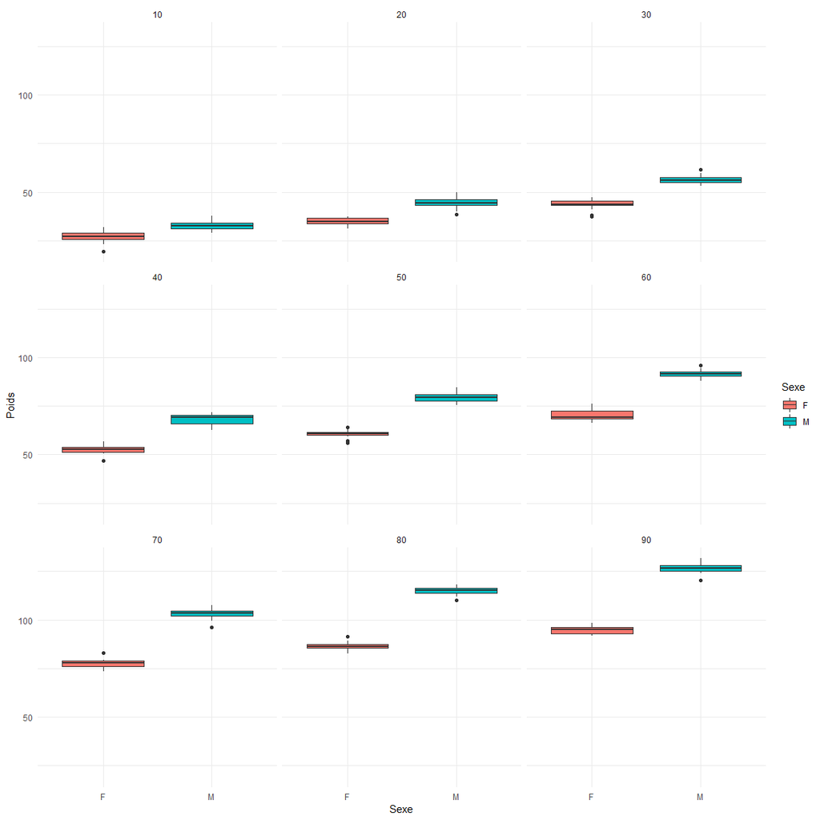

```r
anacov %>% ggplot(aes(y=Poids,x=Sexe,fill=Sexe)) + geom_boxplot() + facet_wrap(~Age) + theme_minimal()
```

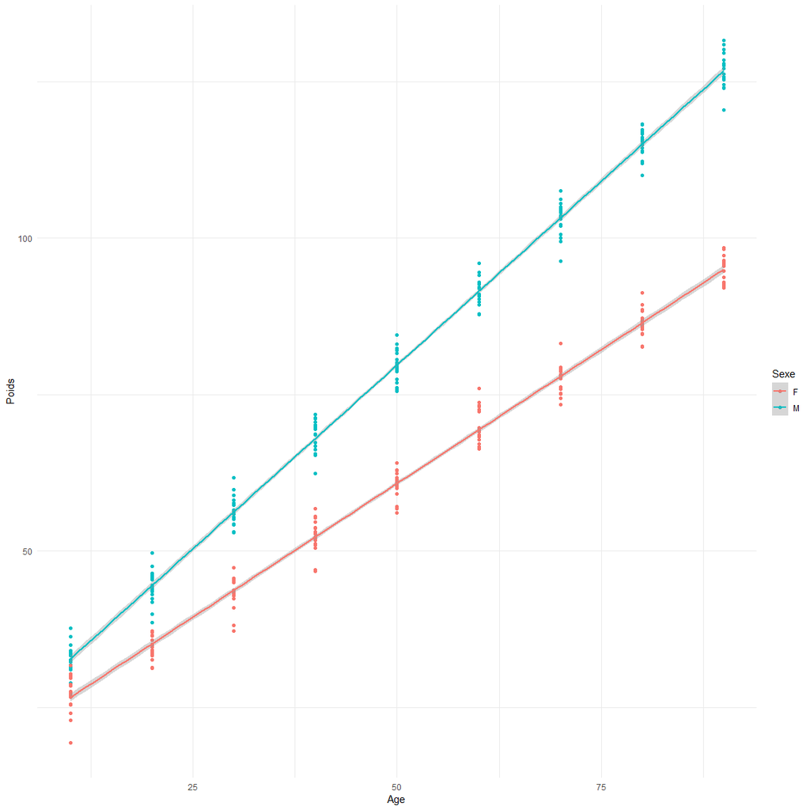

```r
anacov %>% ggplot(aes(x=Age,y=Poids,col=Sexe)) + geom_point() + geom_smooth(method = "lm") + theme_minimal()
```

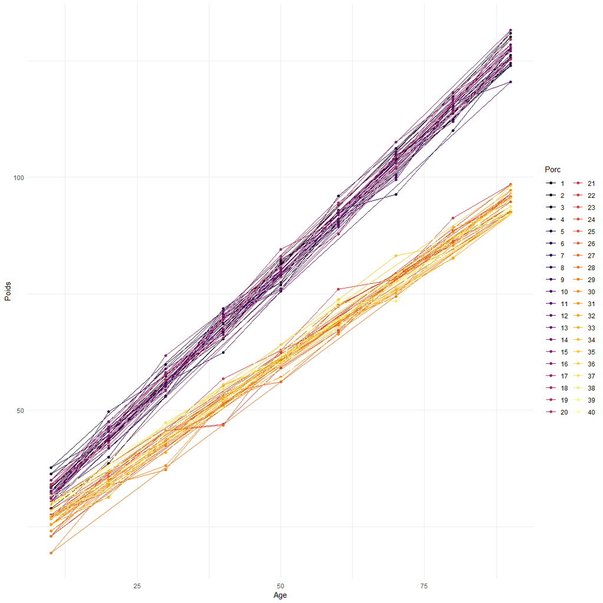

```r
anacov %>% ggplot(aes(x=Age,y=Poids,col=Porc)) + geom_point() + geom_line(group=1) + scale_color_manual(values = inferno(length(unique(anacov$Porc)))) + theme_minimal()
```

```r
anacov %$% table(Porc,Age)
```

```
    Age
Porc 10 20 30 40 50 60 70 80 90
  1   1  1  1  1  1  1  1  1  1
  2   1  1  1  1  1  1  1  1  1
  3   1  1  1  1  1  1  1  1  1
  4   1  1  1  1  1  1  1  1  1
  5   1  1  1  1  1  1  1  1  1
  6   1  1  1  1  1  1  1  1  1
  7   1  1  1  1  1  1  1  1  1
  8   1  1  1  1  1  1  1  1  1
  9   1  1  1  1  1  1  1  1  1
  10  1  1  1  1  1  1  1  1  1
  11  1  1  1  1  1  1  1  1  1
  12  1  1  1  1  1  1  1  1  1
  13  1  1  1  1  1  1  1  1  1
```

[output cut: 27 more lines]

```r
aov <- lm(Poids ~ 1 + Porc%in%Sexe + Sexe + Age + Porc%in%Sexe:Age + Sexe:Age  ,data=anacov)
```

```r
anova(aov)
```

```
Analysis of Variance Table

Response: Poids
               Df Sum Sq Mean Sq    F value    Pr(>F)
Sexe            1  32221   32221  7567.5490 < 2.2e-16 ***
Age             1 246992  246992 58009.9773 < 2.2e-16 ***
Porc:Sexe      38    595      16     3.6770 1.762e-10 ***
Sexe:Age        1   6135    6135  1440.8357 < 2.2e-16 ***
Porc:Sexe:Age  38    172       5     1.0653    0.3736
Residuals     280   1192       4
---
Signif. codes:  0 ‘***’ 0.001 ‘**’ 0.01 ‘*’ 0.05 ‘.’ 0.1 ‘ ’ 1
```

```r
pf(32221/16,1,38,lower.tail = F)
```

```
[1] 1.578769e-34
```

```r
pf(6135/5,1,38,lower.tail = F)
```

```
[1] 1.554702e-30
```

- Porc:Sexe : variation du poids des animaux du même sexe A LA NAISSANCE (pas de facteur Age)
- Sexe : 1.578769e-34 : variation du poids moyen à la naissance est différents entre les sexes
- Age : Pente moyenne indépendamment du sexe
- Porc:Sexe:Age : Au sein du même sexe, pas de différence entre les pentes : pentes parallèles entre porcs male
- Sexe:Age : Pente moyenne entre les sexes sont différentes

Si on utilise pas l’age comme régresseur, on se retrouve avec le même exo que les consultations

# Regression logistique

- Simuler 1000 âges selon une loi uniforme sur [10;80]
- Choisir a et b pour que :

$\frac{e^{a+b80}}{1+e^{a+b80}} = 0.8$

$\frac{e^{a+b10}}{1+e^{a+b10}} = 0.1$

- Simuler l’état de 1000 patients d’âge entre 10 et 80 X = 1 si le patient est malade, 0 si OK

$p = p(X=1) = \frac{e^{a+b\times Age}}{1+e^{a+b\times Age}}$

```r
ages <- runif(1000,min=10,max=80) %>% round()
a <- -2.713
b <- 0.0513
dat <- tibble(
  Age = ages,
  Prob = (exp(a+b*Age))/(1+exp(a+b*Age)),
  Etat = rbinom(1,n = length(Age),prob = Prob)
)
```

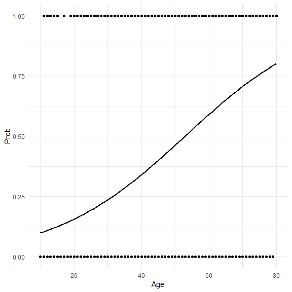

```r
dat %>% ggplot(aes(x=Age,y=Prob)) + geom_line(size=1) + geom_point(aes(x=Age,y=Etat)) + theme_minimal()
```

## Regression logistique entre malade et Age

```r
summary(anaglm)
```

```
Call:
glm(formula = Etat ~ 1 + Age, family = "binomial", data = dat)

Deviance Residuals:
    Min       1Q   Median       3Q      Max
-1.8039  -0.8579  -0.5038   0.8962   2.1767

Coefficients:
             Estimate Std. Error z value Pr(>|z|)
(Intercept) -2.866001   0.205883  -13.92   <2e-16 ***
Age          0.054104   0.003953   13.69   <2e-16 ***
---
Signif. codes:  0 ‘***’ 0.001 ‘**’ 0.01 ‘*’ 0.05 ‘.’ 0.1 ‘ ’ 1

(Dispersion parameter for binomial family taken to be 1)

    Null deviance: 1362.5  on 999  degrees of freedom
Residual deviance: 1124.1  on 998  degrees of freedom
AIC: 1128.1

Number of Fisher Scoring iterations: 3
```

Donc $a=-2.86$ et $b=0.0541$.

$se(a) = 0.205883$ et $se(a) = 0.003953$

$z.value(\frac{(b-0)}{se(b)}) = 13.69$

$z.value(\frac{(a-0)}{se(a)}) = -13.92$

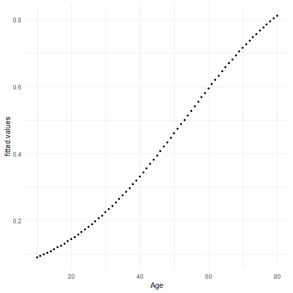

```r
dat %>% mutate(fitted.values = anaglm$fitted.values) %>% ggplot(aes(x=Age,y=fitted.values)) + geom_point(size=1) + theme_minimal()
```

## Suite de l’exo

```r
datsuite <- read_tsv("data_ex_cart.txt") %>% mutate_at(vars(previous_atb,cure),as.factor)
```

```r
anaglm2 <- glm(cure ~ age + previous_atb + AUC_MIC,data=datsuite,family = "binomial")
```

```r
summary(anaglm2)
```

```
Call:
glm(formula = cure ~ age + previous_atb + AUC_MIC, family = "binomial",
    data = datsuite)

Deviance Residuals:
    Min       1Q   Median       3Q      Max
-3.1829  -0.4176   0.1139   0.4244   2.4923

Coefficients:
                 Estimate Std. Error z value Pr(>|z|)
(Intercept)     -0.706558   0.282317  -2.503   0.0123 *
age             -0.044420   0.005669  -7.835 4.68e-15 ***
previous_atbyes -1.746831   0.225285  -7.754 8.91e-15 ***
AUC_MIC          0.032284   0.002050  15.750  < 2e-16 ***
---
Signif. codes:  0 ‘***’ 0.001 ‘**’ 0.01 ‘*’ 0.05 ‘.’ 0.1 ‘ ’ 1

(Dispersion parameter for binomial family taken to be 1)

    Null deviance: 1335.69  on 999  degrees of freedom
Residual deviance:  634.55  on 996  degrees of freedom
AIC: 642.55

Number of Fisher Scoring iterations: 6
```

```r
a <- -0.706558
b <- -0.044420
c <- -1.746831
d <- 0.032284
my.formula <- function(agei,patbi,auc_mici){
  patbi <- ifelse(patbi == "no",0,1)
  sub.formula <- exp(a+b*agei+c*patbi+d*auc_mici)
  (sub.formula/(1+sub.formula))
}
```

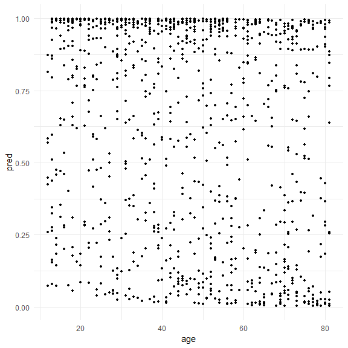

```r
datsuite %>% ggplot(aes(x=age,y=pred)) + geom_point(size=1) + theme_minimal()
```

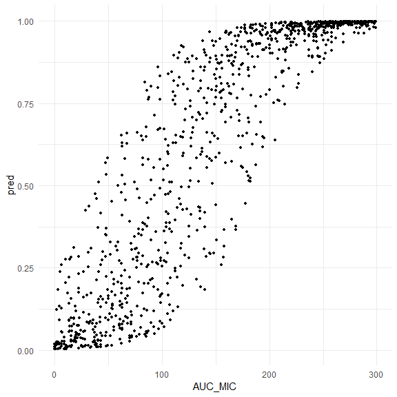

```r
datsuite %>% ggplot(aes(x=AUC_MIC,y=pred)) + geom_point(size=1) + theme_minimal()
```

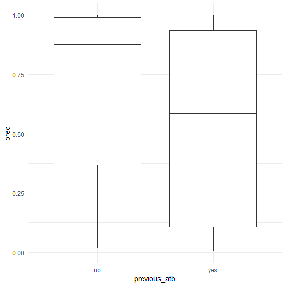

```r
datsuite %>% ggplot(aes(x=previous_atb,y=pred)) + geom_boxplot() + theme_minimal()
```

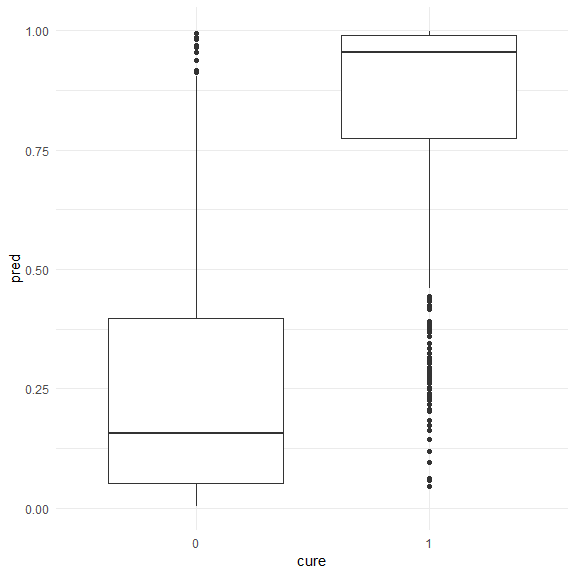

```r
datsuite %>% ggplot(aes(x=cure,y=pred)) + geom_boxplot() + theme_minimal()
```

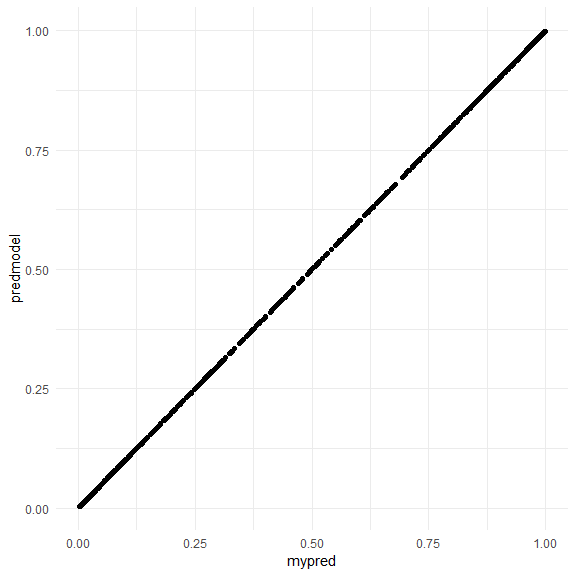

```r
tibble(predmodel = anaglm2$fitted.values,mypred = datsuite$pred) %>% ggplot(aes(x=mypred,y=predmodel)) + geom_point() + theme_minimal()
```

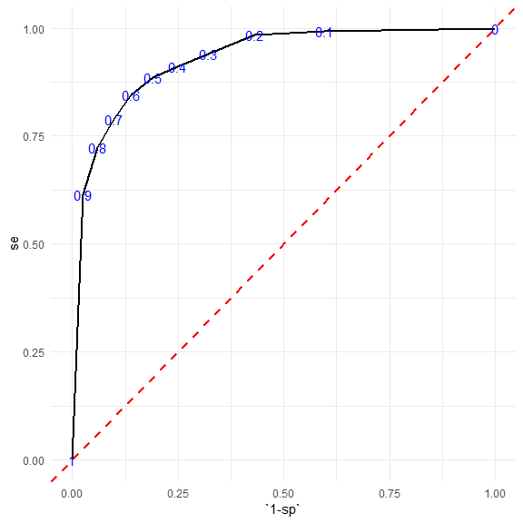

### Avec interactions

```r
anaglm2 <- glm(cure ~ 1 +previous_atb + AUC_MIC+ age + previous_atb:AUC_MIC + previous_atb:age ,data=datsuite,family = "binomial")
```

```r
summary(anaglm2)
```

```
Call:
glm(formula = cure ~ 1 + previous_atb + AUC_MIC + age + previous_atb:AUC_MIC +
    previous_atb:age, family = "binomial", data = datsuite)

Deviance Residuals:
    Min       1Q   Median       3Q      Max
-3.1166  -0.4083   0.1143   0.4141   2.5432

Coefficients:
                         Estimate Std. Error z value Pr(>|z|)
(Intercept)             -0.618803   0.381669  -1.621  0.10495
previous_atbyes         -1.971987   0.569093  -3.465  0.00053 ***
AUC_MIC                  0.030803   0.002876  10.711  < 2e-16 ***
age                     -0.043400   0.008036  -5.401 6.63e-08 ***
previous_atbyes:AUC_MIC  0.002847   0.004101   0.694  0.48756
previous_atbyes:age     -0.002203   0.011359  -0.194  0.84620
---
Signif. codes:  0 ‘***’ 0.001 ‘**’ 0.01 ‘*’ 0.05 ‘.’ 0.1 ‘ ’ 1

(Dispersion parameter for binomial family taken to be 1)

    Null deviance: 1335.69  on 999  degrees of freedom
Residual deviance:  634.06  on 994  degrees of freedom
AIC: 646.06

Number of Fisher Scoring iterations: 6
```

La probabilité d’être guéri est diminué quand ils ont pris des antibiotiques avant (previous_atbyes pval) quelque soit l’âge des patients (pval previous_atbyes). L’âge seul agit sur la probabilité d’être guéri (coeff negatif, sign)

```r
mu <- -0.618803
a <- -1.971987
b <- 0.030803
c <- -0.043400
d <- 0.002847
e <- -0.002203
my.formula <- function(agei,patbi,auc_mici){
  patbi <- ifelse(patbi == "no",0,1)
  sub.formula <- exp(mu+a*patbi+b*auc_mici+c*agei+(d*patbi*auc_mici)+(e*patbi*agei))
  (sub.formula/(1+sub.formula))
}
datsuite <- datsuite %>% mutate(pred = my.formula(agei=age,patbi=previous_atb,auc_mici = AUC_MIC))
```

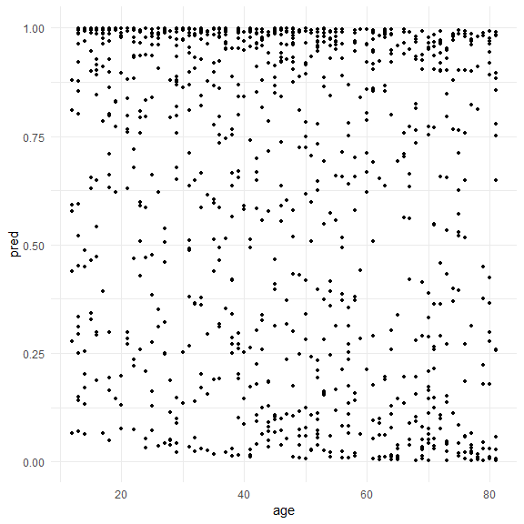

```r
datsuite %>% ggplot(aes(x=age,y=pred)) + geom_point(size=1) + theme_minimal()
```

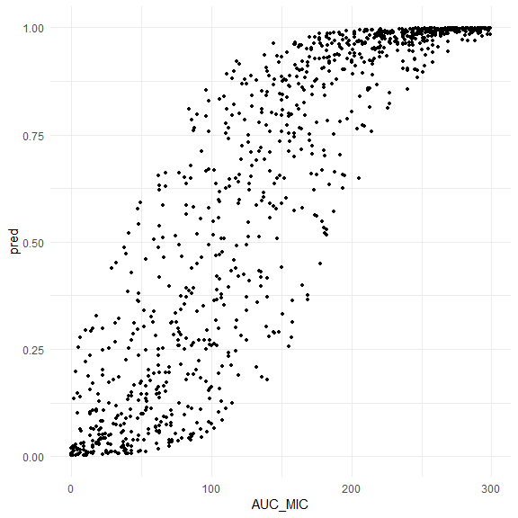

```r
datsuite %>% ggplot(aes(x=AUC_MIC,y=pred)) + geom_point(size=1) + theme_minimal()
```

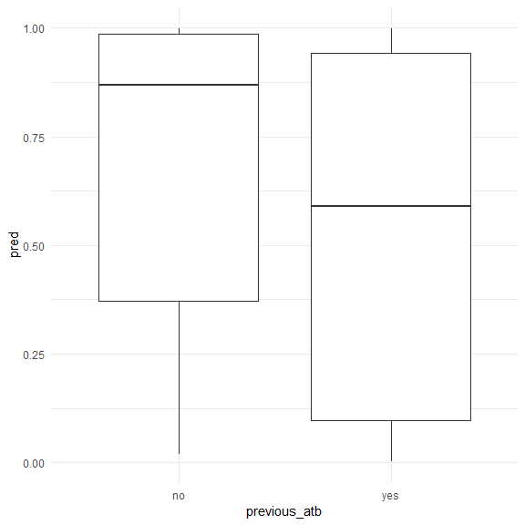

```r
datsuite %>% ggplot(aes(x=previous_atb,y=pred)) + geom_boxplot() + theme_minimal()
```

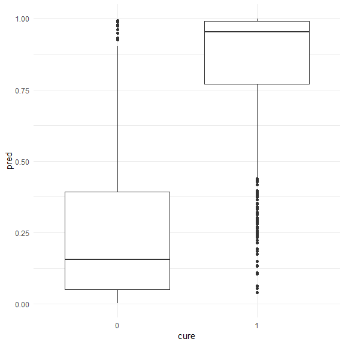

```r
datsuite %>% ggplot(aes(x=cure,y=pred)) + geom_boxplot() + theme_minimal()
```

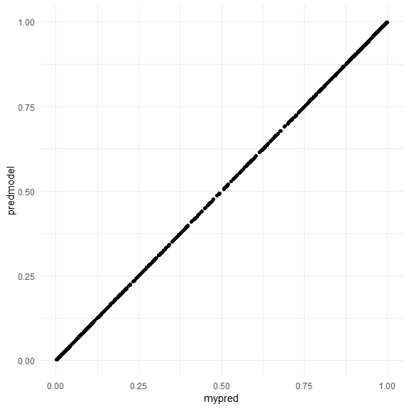

```r
tibble(predmodel = anaglm2$fitted.values,mypred = datsuite$pred) %>% ggplot(aes(x=mypred,y=predmodel)) + geom_point() + theme_minimal()
```

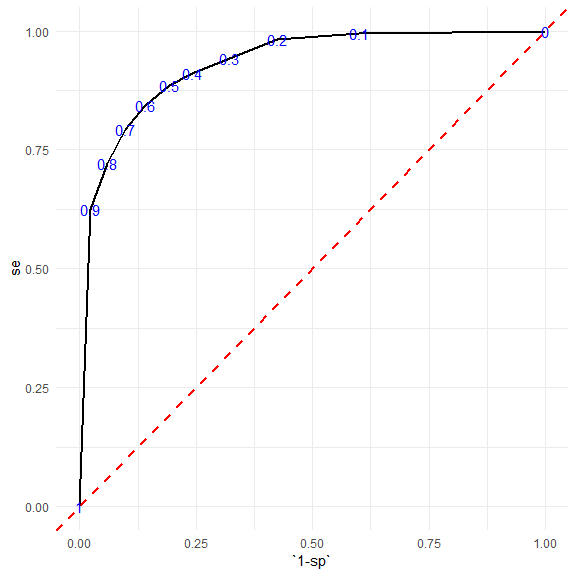

```r
build_ROC <- lapply(seq(0.0,1,by=0.1),function(i){
  cc <- datsuite %>% mutate(predrounded = ifelse(pred > i,1,0)) %>% count(cure,predrounded)
  a <- cc %>% filter(cure == 0, predrounded == 0) %>% pull(n)
  a <- ifelse(length(a)==0,0,a)
  b <- cc %>% filter(cure == 0, predrounded == 1) %>% pull(n)
  b <- ifelse(length(b)==0,0,b)
  c <- cc %>% filter(cure == 1, predrounded == 0) %>% pull(n)
  c <- ifelse(length(c)==0,0,c)
  d <- cc %>% filter(cure == 1, predrounded == 1) %>% pull(n)
  d <- ifelse(length(d)==0,0,d)
  tibble(se = (d/(c+d)),
         sp = (a/(a+b)),
         `1-sp`=1-sp,
         seuil = i)
}) %>% bind_rows()
build_ROC  %>% ggplot(aes(x=`1-sp`,y=se)) + geom_line(size=1) + theme_minimal() + geom_abline(intercept = 0,slope=1,col="red",linetype="dashed",size=1) + geom_text(aes(label=seuil),col="blue")
```